# Homework1 Chapter2 and Chapter3

#### (P5)

Linear regression model with salary as outcome variable and employees rating as predictor variable, includes least squares line:

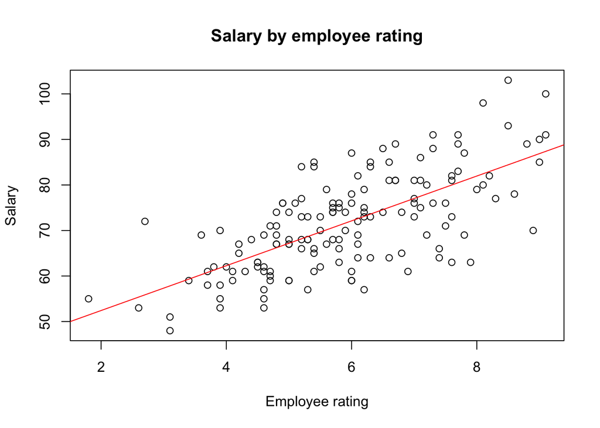

```
##
## Call:
## lm(formula = manager$salary ~ manager$mrating)
##
## Residuals:
##      Min       1Q   Median       3Q      Max
## -18.4792  -4.5974  -0.1979   4.8511  18.5660
##
## Coefficients:
##                 Estimate Std. Error t value Pr(>|t|)
## (Intercept)      42.5750     2.6289    16.2   <2e-16 ***
## manager$mrating   4.9246     0.4321    11.4   <2e-16 ***
## ---
## Signif. codes:  0 '***' 0.001 '**' 0.01 '*' 0.05 '.' 0.1 ' ' 1
##
## Residual standard error: 7.838 on 148 degrees of freedom
## Multiple R-squared:  0.4674, Adjusted R-squared:  0.4638
## F-statistic: 129.9 on 1 and 148 DF,  p-value: < 2.2e-16
```

The slope of this model is 4.9245782 which means that with every rating unit an employee goes up, salary increases by 4.9245782.

#### (P6)

My estimate of the average salary for an employee with rating 3 is: 57.3487734. Since the estimated average salary for an employee with rating 6 is 72.1225081, the estimated difference in average salary for the employee with rating 3 and another with rating 6 is 14.7737347. Employees with higer ratings tend to have higher salaries.

#### (P7)

The residual sum of squares for the regresion model comparing salary with employee rating is 9092.3435599.

The regression line with intercept 40 and slope 5.5 looks like this:

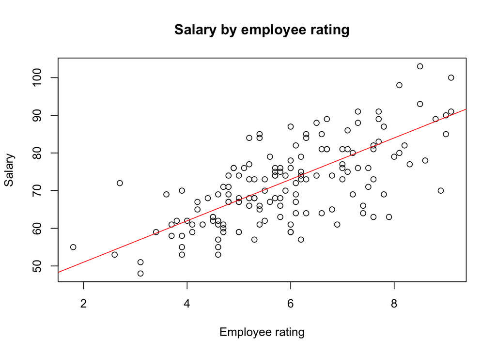

The residual sum of squares for the regression model comparing salary with employee rating with intercept set at 40 and slope set to 5.5 is 9302.2175 which is higher than the residual sum of squares for the least squares estimate.

#### (P8)

The average salary for an employee with rating 10 is 91.8208211. However in the dataset we have employees with higher salaries than this at lower ratings and no one has rating 10. Ratings can not go any higher than 10 but the regression model can. We can expect an employe with rating 10 to have the highest salary.

## Chapter 3

#### (P3)

The average salary for an employee with rating 3.5 is 59.8110625 while the average salary for an employee with salary 8.5 is 84.4339537.

#### (P4)

The lower limit for the 95% mean interval for rating 2.5 is 43.8359474 and the upper is 65.8900856, while the lower limit for rating 8.4 is 69.6987802 and the upper is 98.1654696. The two intervals do not overlap.

#### (P5)

The average salary for employees with rating 5.9 is 72.

#### (P6)

The graph representing the relationship between the amount of a bill and tips looks lke the following:

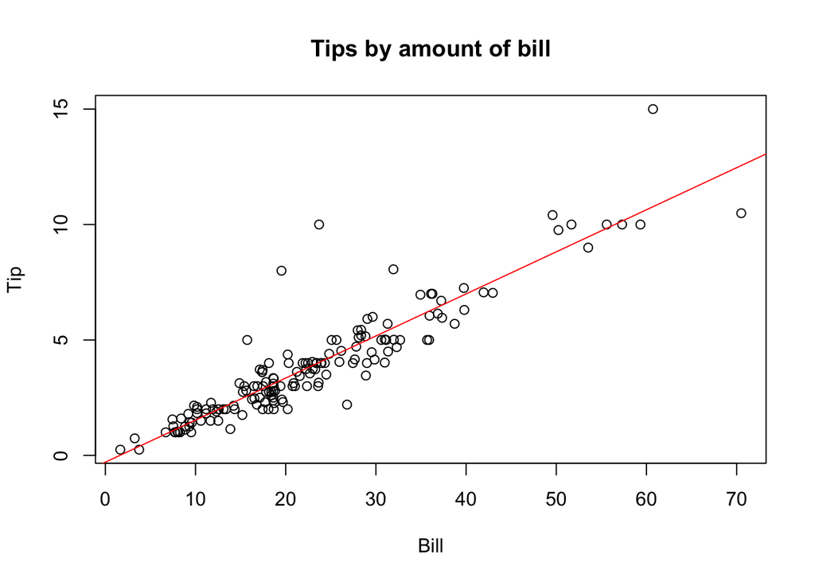

```
##
## Call:
## lm(formula = restauranttips$Tip ~ restauranttips$Bill)
##
## Residuals:
##     Min      1Q  Median      3Q     Max
## -2.3911 -0.4891 -0.1108  0.2839  5.9738
##
## Coefficients:
##                      Estimate Std. Error t value Pr(>|t|)
## (Intercept)         -0.292267   0.166160  -1.759   0.0806 .
## restauranttips$Bill  0.182215   0.006451  28.247   <2e-16 ***
## ---
## Signif. codes:  0 '***' 0.001 '**' 0.01 '*' 0.05 '.' 0.1 ' ' 1
##
## Residual standard error: 0.9795 on 155 degrees of freedom
## Multiple R-squared:  0.8373, Adjusted R-squared:  0.8363
## F-statistic: 797.9 on 1 and 155 DF,  p-value: < 2.2e-16
```

The average tip for a bill that is 40 is 6.9963219.

## Code Appendix

```r
### (P1)
#load data and plot
library(readxl)
manager <- read_excel("~/Downloads/manager.xlsx")

plot(manager$mrating, manager$salary, main = "Salary by employee rating", xlab = "Employee Rating", ylab = "Salary")


plot(manager$yearsexp, manager$salary, main = "Salary by employee years of experience", xlab = "Years of experience", ylab = "Salary")

###(P2)
#regression model salary on years

salary_years_model <- lm(manager$salary ~ manager$yearsexp)
summary(salary_years_model)

intercept <- coef(lm(salary_years_model))["(Intercept)"]

slope <- coef(lm(salary_years_model))["manager$yearsexp"]

###(P3)
#average estimates

estimate_mean <- function(x) {
  y <- intercept + slope * x
  y
}

estimate5 <- estimate_mean(5)
estimate15 <- estimate_mean(15)

diff_salary <- estimate5 - estimate15

###(P4)
#estimates
estimate7 <- estimate_mean(7)
estimate17 <- estimate_mean(17)

diff_salary2 <- estimate7 - estimate17

###(P5)
#regression model salary on rating and plot
plot(manager$mrating, manager$salary, main = "Salary by employee rating", xlab = "Employee rating", ylab = "Salary")

salary_rating_model <- lm(manager$salary ~ manager$mrating)
abline(salary_rating_model, col = "red")
summary(salary_rating_model)

intercept2 <- coef(lm(salary_rating_model))["(Intercept)"]

slope2 <- coef(lm(salary_rating_model))["manager$mrating"]

###(P6)
#estimates
estimate_mean2 <- function(x){
  y <- intercept2 + slope2 * x
  y
}

estimate3 <- estimate_mean2(3)
estimate6 <- estimate_mean2(6)

diff_rating <- estimate6 - estimate3

###(P7)
#residual sum of squares
rss <- anova(salary_rating_model)["Residuals", "Sum Sq"]

#set intercept and slope to 40 and 5.5 respectivly
plot(manager$mrating, manager$salary, main = "Salary by employee rating", xlab = "Employee rating", ylab = "Salary")
abline(salary_rating_model, coef = c(40, 5.5), col = "red")

rss2 <- sum((manager$salary - (40 + 5.5 * manager$mrating))^2)
###(P8)
estimate10 <- estimate_mean2(10)


###(P1)
#Salary on years of experience t-test, p-value at alpha = 0.05
n = length(manager$salary)

estimate_B <- function(X, Y){
  Xbar <- mean(X)
  Ybar <- mean(Y)
  b1hat <- sum((X - Xbar) * (Y - Ybar)) / sum ((X - Xbar)^2)
  b0hat <- Ybar - b1hat * Xbar
  return(c(b0hat, b1hat))
}

result = estimate_B(manager$yearsexp, manager$salary)
beta1_hat = result[2]
beta0_hat = result[1]

MSE = sum((manager$salary - (beta0_hat - beta1_hat * manager$yearsexp))^2) / (n - 2)
se_beta1_hat = sqrt(MSE / sum((manager$yearsexp - mean(manager$yearsexp))^2))

t_value <- (beta1_hat - 0) / se_beta1_hat

# t(alpha=0.025, n - 2)
###(P2)
#Salary on rating t-test, p-value on alpha = 0.05

result2 = estimate_B(manager$mrating, manager$salary)
beta1_hat2 = result2[2]
beta0_hat2 = result2[1]

MSE2 = sum((manager$salary - (beta0_hat2 - beta1_hat2 * manager$mrating))^2) / (n - 2)
se_beta1_hat2 = sqrt(MSE2 / sum((manager$mrating - mean(manager$mrating))^2))

t_value2 <- (beta1_hat2 - 0) / se_beta1_hat2

# t(0.05, n - 2)
#estimates
estimate3.5 <- estimate_mean2(3.5)
estimate8.5 <- estimate_mean2(8.5)

###(P3)
# Mean confidence interval
RDG = function(b0, b1, X, sigma){
  n = length(X)
  Y = b0 + b1 * X + rnorm(n, sd = sigma)
  return(Y)
}

M = 10000
x_h = 3.5

X = runif(n,0,10)
sigma = 0.5
alpha = 0.05
total = 0

for (i in 1:M){
  ## generate a random sample
  Y = RDG(intercept2, slope2, X, sigma)

  ## get beta1_hat & beta0_hat
  result1 = estimate_B(X, Y)
  beta1_hatt = result1[2]
  beta0_hatt = result1[1]

  ## s.e.(beta0_hat + beta1_hat*x_h)
  MSE1 = sum((Y - (beta0_hatt - beta1_hatt * X))^2) / (n - 2)
  se1 = sqrt(MSE1 * (1/n + (mean(X) - x_h)^2 / sum((X - mean(X))^2)))

  ## C.I.
  lower3.5 = beta0_hatt + beta1_hatt * x_h - se1*qt(1-alpha/2, n - 2)
  upper3.5 = beta0_hatt + beta1_hatt * x_h + se1*qt(1-alpha/2, n - 2)

  ## whether the true parameter (beta0 + beta1*x_h) is within the C.I.
  total = total + 1*((intercept2 + slope2 * x_h >= lower3.5) & (intercept2 + slope2 * x_h <= upper3.5))
}


x2_h <- 8.5
total1 = 0

for (i in 1:M){
  ## generate a random sample
  Y1 = RDG(intercept2, slope2, X, sigma)

  ## get beta1_hat & beta0_hat
  resultt = estimate_B(X, Y1)
  beta1_hatt2 = resultt[2]
  beta0_hatt2 = resultt[1]

  ## s.e.(beta0_hat + beta1_hat*x_h)
  MSE12 = sum((Y - (beta0_hatt2 - beta1_hatt2 * X))^2) / (n - 2)
  se2 = sqrt(MSE12 * (1/n + (mean(X) - x2_h)^2 / sum((X - mean(X))^2)))

  ## C.I.
  lower8.5 = beta0_hatt2 + beta1_hatt2 * x2_h - se2*qt(1-alpha/2, n-2)
  upper8.5 = beta0_hatt2 + beta1_hatt2 * x2_h + se2*qt(1-alpha/2, n-2)

  ## whether the true parameter (beta0 + beta1*x_h) is within the C.I.
  total1 = total1 + 1*((intercept2 + slope2 * x2_h >= lower8.5) & (intercept2 + slope2 * x2_h <= upper8.5))
}

####(P4)
#Prediction interval
x3_h <- 2.5
total3 = 0

for (i in 1:M){
  ## generate a random sample
  Y3 = RDG(intercept2, slope2, X, sigma)

  ## get beta1_hat & beta0_hat
  result3 = estimate_B(X, Y3)
  beta1_hatt3 = result3[2]
  beta0_hatt3 = result3[1]

  ## s.e.(beta0_hat + beta1_hat*x_h)
  MSE3 = sum((Y - (beta0_hatt3 - beta1_hatt3 * X))^2) / (n - 2)
  se3 = sqrt(MSE3 * (1/n + (mean(X) - x3_h)^2 / sum((X - mean(X))^2)))

  ## C.I.
  lower2.5 = beta0_hatt3 + beta1_hatt3 * x3_h - se3*qt(1-alpha/2, n-2)
  upper2.5 = beta0_hatt3 + beta1_hatt3 * x3_h + se3*qt(1-alpha/2, n-2)

  ## whether the true parameter (beta0 + beta1*x_h) is within the C.I.
  total3 = total3 + 1*((intercept2 + slope2 * x3_h >= lower2.5) & (intercept2 + slope2 * x3_h <= upper2.5))
}

x4_h <- 8.4
total4 = 0

for (i in 1:M){
  ## generate a random sample
  Y4 = RDG(intercept2, slope2, X, sigma)

  ## get beta1_hat & beta0_hat
  result4 = estimate_B(X, Y4)
  beta1_hatt4 = result4[2]
  beta0_hatt4 = result4[1]

  ## s.e.(beta0_hat + beta1_hat*x_h)
  MSE4 = sum((Y4 - (beta0_hatt4 - beta1_hatt4 * X))^2) / (n - 2)
  se4 = sqrt(MSE4 * (1/n + (mean(X) - x4_h)^2 / sum((X - mean(X))^2)))

  ## C.I.
  lower8.4 = beta0_hatt4 + beta1_hatt4 * x4_h - se4*qt(1-alpha/2, n-2)
  upper8.4 = beta0_hatt4 + beta1_hatt4 * x4_h + se4*qt(1-alpha/2, n-2)

  ## whether the true parameter (beta0 + beta1*x_h) is within the C.I.
  total4 = total4 + 1*((intercept2 + slope2 * x4_h >= lower8.4) & (intercept2 + slope2 * x4_h <= upper8.4))
}

###(P5)
#find out what the average salary is based on the usual sample statistics of mean and standard deviations of your data.
sample5.9 <- manager$salary[which(manager$mrating == 5.9)]
length_sample <- length(sample5.9)
average_salary <- sum(sample5.9) / length_sample

sd_5.9 <- sqrt((sum(sample5.9 - average_salary)^2) / length_sample)

###(P6)
#regression model tips on bill and plot
library(readr)
restauranttips <- read_csv("restauranttips.csv")

plot(restauranttips$Bill, restauranttips$Tip, main = "Tips by amount of bill", ylab = "Tip", xlab = "Bill")

tip_bill_model <- lm(restauranttips$Tip ~ restauranttips$Bill)
abline(tip_bill_model, col = 'red')

summary(tip_bill_model)

#t-test to assess whether there is a linear relationship between the amount of the bill and the amount of the tip
N = length(restauranttips$Bill)

result8 = estimate_B(restauranttips$Bill, restauranttips$Tip)
beta1_hat8 = result8[2]
beta0_hat8 = result8[1]

MSE8 = sum((restauranttips$Tip - (beta0_hat8 - beta1_hat8 * restauranttips$Bill))^2) / (N - 2)
se_beta1_hat8 = sqrt(MSE8 / sum((restauranttips$Bill - mean(restauranttips$Bill))^2))

t_value8 <- (beta1_hat8 - 0) / se_beta1_hat8

# t(0.05, N - 2)
result6 = estimate_B(restauranttips$Bill, restauranttips$Tip)
beta1_hat6 = result6[2]
beta0_hat6 = result6[1]

intercept6 <- coef(lm(tip_bill_model))["(Intercept)"]
slope6 <- coef(lm(tip_bill_model))["restauranttips$Bill"]



#CI for slope
total6 = 0
X6 = runif(n,0,15)

for (i in 1:M){
  ## generate a random sample
  Y6 = RDG(intercept6, slope6, X6, sigma)

  ## get beta1_hat & beta0_hat
  result6 = estimate_B(X6, Y6)
  beta1_hat6 = result6[2]
  beta0_hat6 = result6[1]

  ## s.e.(beta1_hat)
  MSE6 = sum((Y6 - beta0_hat6 - beta1_hat6 * X6)^2) / (N - 2)
  se_beta1_hat6 = sqrt(MSE6 / sum((X6 - mean(X6))^2))

  ## C.I. for beta1
  lowerb = beta1_hat6 - se_beta1_hat6 * qt(1-alpha/2, N - 2)
  upperb = beta1_hat6 + se_beta1_hat6 * qt(1-alpha/2, N - 2)

  ## whether the true parameter beta1 is within the C.I.
  total6 = total6 + 1*((slope6 >= lowerb) & (slope6 <= upperb))
}

#Predict average tip for a bill that was 40
estimate_mean6 <- function(x) {
  y = intercept6 + slope6 * x
  y
}
estimate40 <- estimate_mean6(40)

#Find the mean interval for a bill that was 40.
x6_h = 40
total7 = 0

for (i in 1:M){
  ## generate a random sample
  Y7 = RDG(intercept6, slope6, X6, sigma)

  ## get beta1_hat & beta0_hat
  result7 = estimate_B(X6, Y7)
  beta1_hat7 = result7[2]
  beta0_hat7 = result7[1]

  ## s.e.(beta0_hat + beta1_hat*x_h)
  MSE7 = sum((Y7 - (beta0_hat7 - beta1_hat7 * X6))^2) / (N - 2)
  se7 = sqrt(MSE7 * (1/N + (mean(X6) - x6_h)^2 / sum((X6 - mean(X6))^2)))

  ## C.I.
  lower40 = beta0_hat7 + beta1_hat7 * x6_h - se7*qt(1-alpha/2, N-2)
  upper40 = beta0_hat7 + beta1_hat7 * x6_h + se7*qt(1-alpha/2, N-2)

  ## whether the true parameter (beta0 + beta1*x_h) is within the C.I.
  total7 = total7 + 1*((intercept6 + slope6 * x6_h >= lower40) & (intercept6 + slope6 * x6_h <= upper40))
}
```